# Final Project: International Cancer Incidence and Mortality

Rhoda Jiao and Maytee Chantharayukhont

The following data is based on a set of 22 data sets detailing in cancer incidence (new cases per 100,000 people) and mortality (deaths per 100,000 people) in countries across the world from about 1960 to 2002. This data was collected by the International Agency for Research on Cancer and the World Health Organization. An additional 4 tables were joined to these data sets discussing continent, gross domestic profit, human development index (HDI), and life expectancy.

First, we reformatted the .xlsx files containing the data sets in R and uploaded them into the Oracle database using SQL Developer. We then visualized our data in R and Tableau.

The first ten rows of each of our data sets are shown below.

```r
source("../01 Data/libraries.R")
source("../01 Data/healthdata.R")
```

```
## Source: local data frame [2,779 x 3]
##
##        COUNTRY YEAR BREAST_FEMALE_MORTALITY
## 1      Hungary 1962                   13.58
## 2      Iceland 1962                   28.50
## 3      Ireland 1962                   20.77
## 4        Italy 1962                   15.24
## 5        Japan 1962                    3.75
## 6    Mauritius 1962                    4.09
## 7       Mexico 1962                    3.86
## 8  Netherlands 1962                   23.76
## 9  New Zealand 1962                   21.83
## 10   Nicaragua 1962                    0.38
## ..         ...  ...                     ...
## Source: local data frame [561 x 3]
```

[output cut: 351 more lines]

# **R**

In R, we joined our data sets by country and year and used data wrangling to create the date frames we needed for the visualizations we created.

```r
source("../02 Data Wrangling/wrangling.R")
```

```
## Source: local data frame [257 x 34]
##
##        COUNTRY YEAR BREAST_FEMALE_MORTALITY BREAST_FEMALE_INCIDENCE
## 1  Afghanistan 2002                   11.70                    26.8
## 2      Albania 2002                    6.54                    57.4
## 3      Algeria 2002                   16.70                    23.5
## 4       Angola 2002                   17.10                    23.1
## 5    Argentina 2002                   19.42                    73.9
## 6      Armenia 2002                   22.09                    51.6
## 7    Australia 2002                   16.43                    83.2
## 8      Austria 2002                   17.52                    70.5
## 9   Azerbaijan 2002                   10.34                    31.5
## 10     Bahrain 2002                   17.70                    40.2
## ..         ...  ...                     ...                     ...
## Variables not shown: CERVIX_FEMALE_MORTALITY (dbl),
##   CERVIX_FEMALE_INCIDENCE (dbl), COLON_FEMALE_MORTALITY (dbl),
##   COLON_FEMALE_INCIDENCE (dbl), COLON_MALE_MORTALITY (dbl),
##   COLON_MALE_INCIDENCE (dbl), LIVER_FEMALE_MORTALITY (dbl),
##   LIVER_FEMALE_INCIDENCE (dbl), LIVER_MALE_MORTALITY (dbl),
##   LIVER_MALE_INCIDENCE (dbl), LUNG_FEMALE_MORTALITY (dbl),
##   LUNG_FEMALE_INCIDENCE (dbl), LUNG_MALE_MORTALITY (dbl),
##   LUNG_MALE_INCIDENCE (dbl), PROSTATE_MALE_MORTALITY (dbl),
##   PROSTATE_MALE_INCIDENCE (dbl), STOMACH_FEMALE_MORTALITY (dbl),
##   STOMACH_FEMALE_INCIDENCE (dbl), STOMACH_MALE_MORTALITY (dbl),
##   STOMACH_MALE_INCIDENCE (dbl), LIFE_EXPECTANCY (dbl), INDUSTRYSHAREGDP
##   (fctr), AGRICULTURESHAREGDP (fctr), SERVICESSHAREGDP (fctr), RANK1SECTOR
##   (fctr), RANK2SECTOR (fctr), RANK3SECTOR (fctr), HDINUMBER (dbl),
##   HDICATEGORY (fctr), CONTINENT (fctr)
```

```r
source("../03 Visualizations/crosstabs.R")
```

[output not shown]

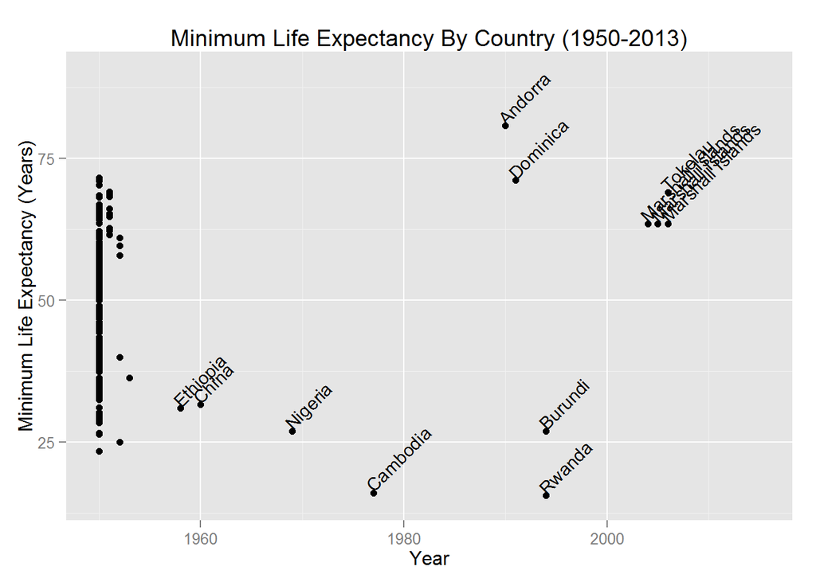

```
## [1] "These three visualizations show scatterplots of the male to female mortality of specific types of cancer. Each is facet wrapped by continent."
```

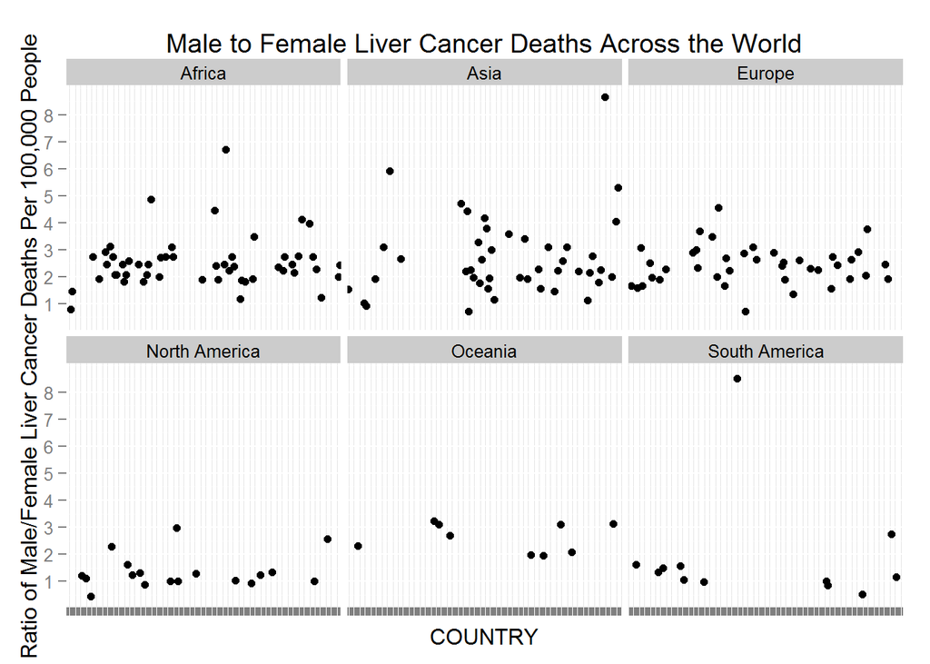

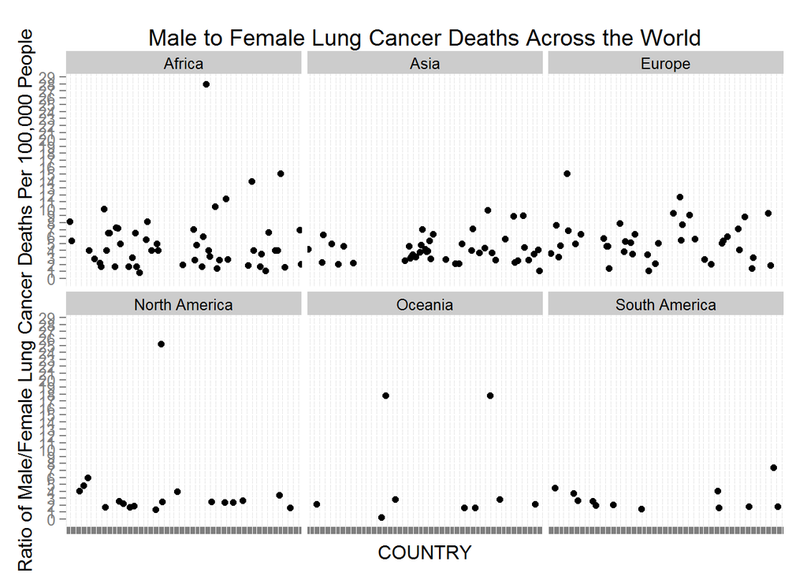

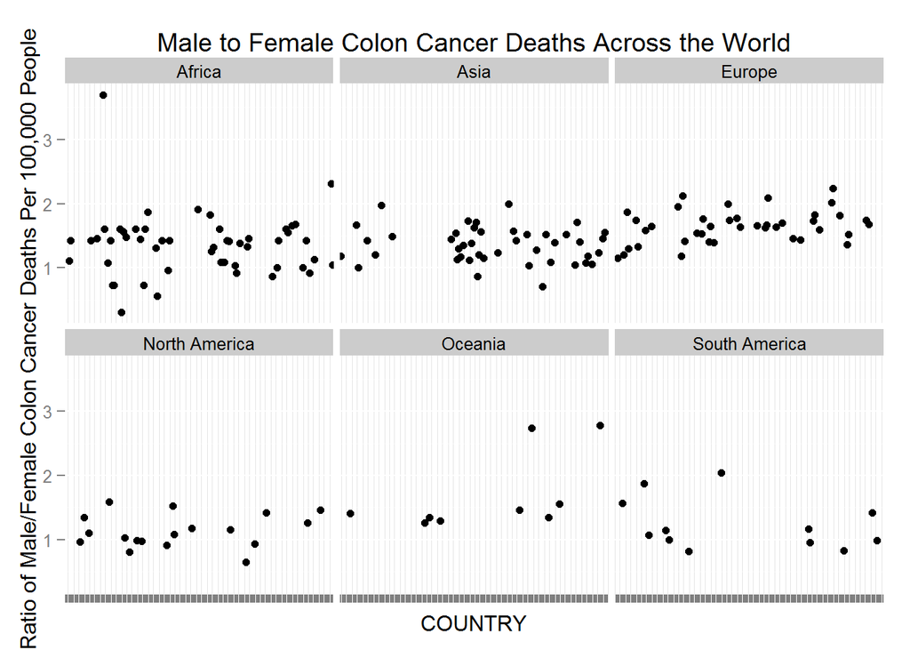

[output not shown]

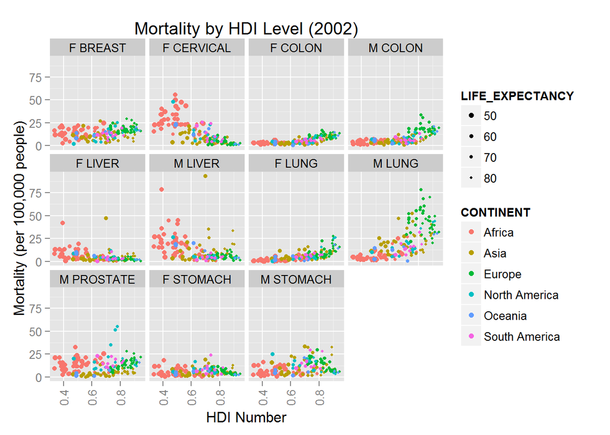

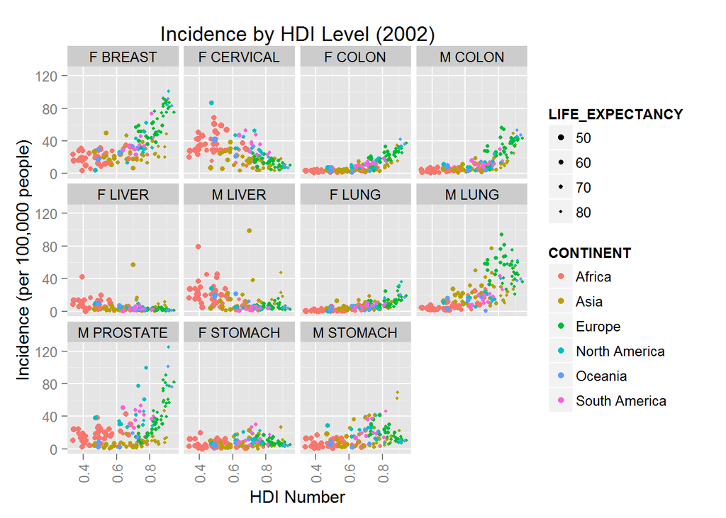

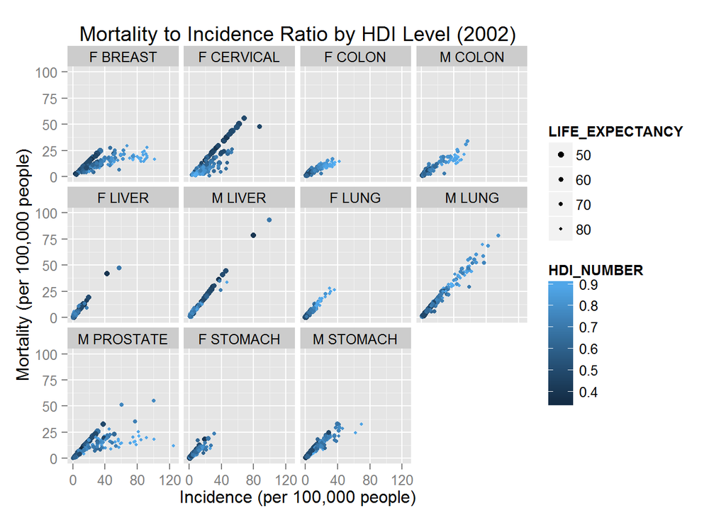

```r
source("../03 Visualizations/viz.R")
```

# **Tableau**

In Tableau, we used full outer joins to connect our data by country and by year, using life_expectancy as our root table. We used that data for the following visualizations.

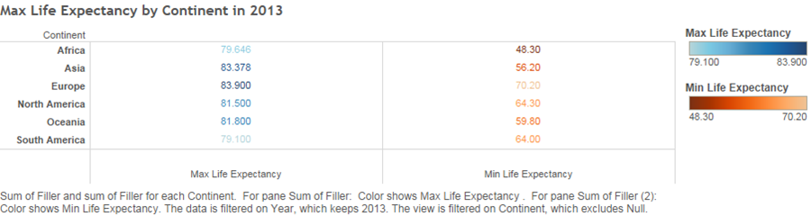

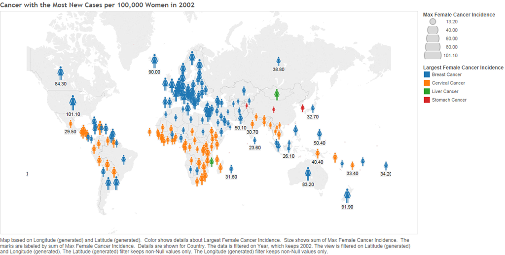

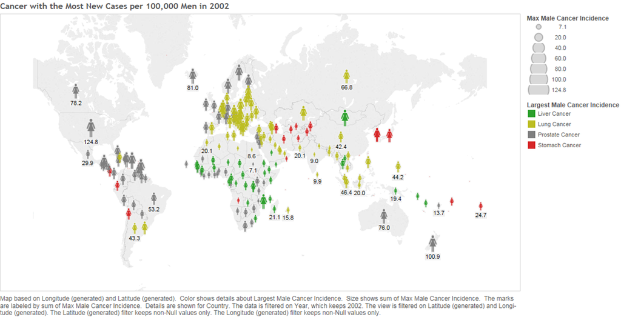

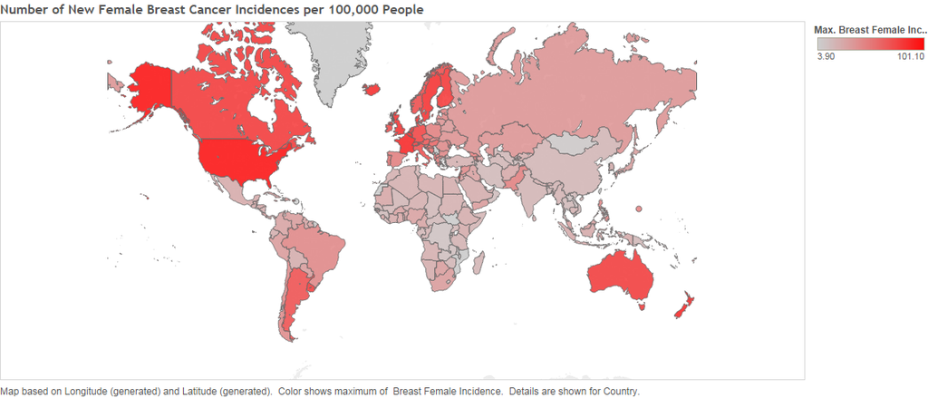

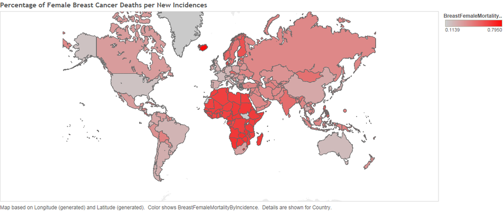

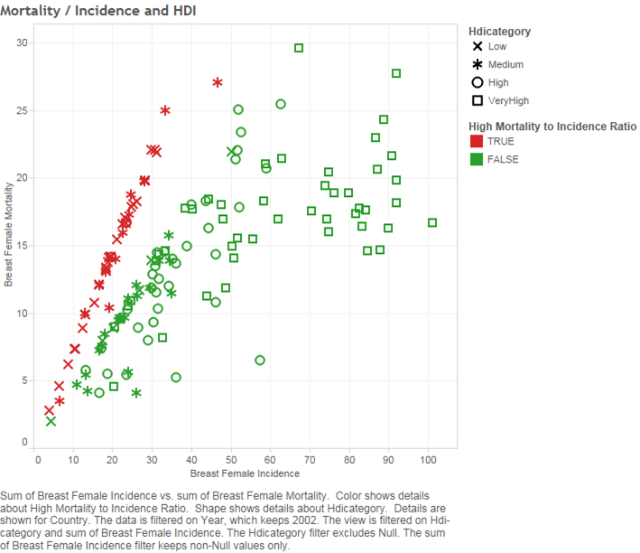

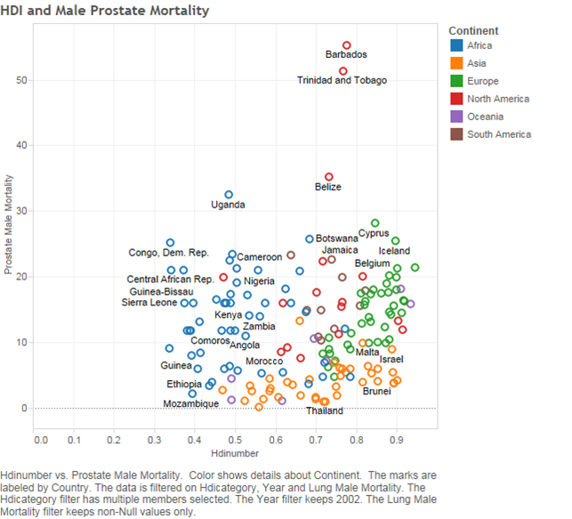

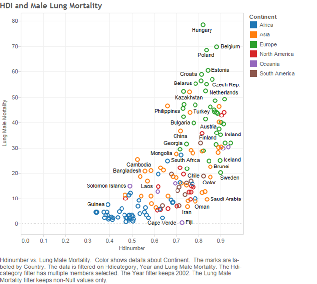

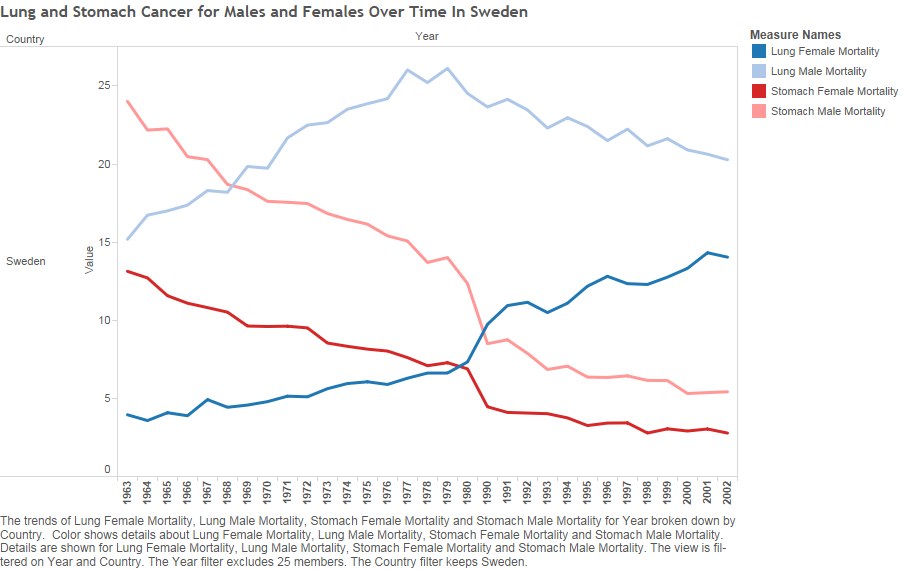

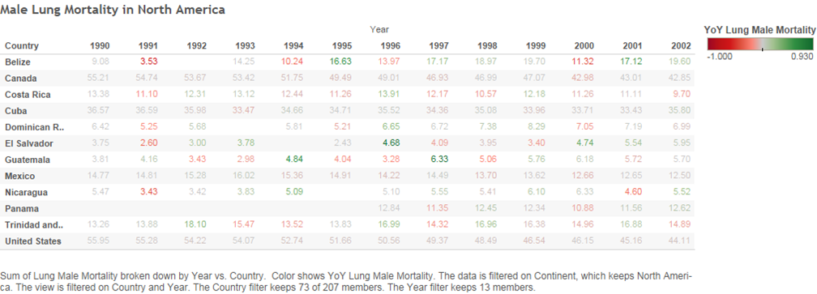